# Data Exploration

Data exploration is a crucial first step in any machine learning workflow, helping data scientists understand the structure, quality, and patterns in the data. In this note, we will perform the following data exploration steps.

- Read
- Inspect
- Subset
- Edit
- Summarize
- Visualize

```python
import numpy as np
import matplotlib.pyplot as plt
import pandas as pd
```

## Read Data

Pandas has a number of read_ functions to ingest data from a number of different data formats. We will rely on the read_csv() function as most datasets come in a text based comma-separated values format. However, it is worth mentioning that binary formats like parquet tend to be much more compact than text-based files and they do a better job saving additional meta data like variable types.

```python
import pandas
for fname in dir(pandas):
    if not fname.startswith('read_'):
        continue
    print(fname)
```

```
read_clipboard
read_csv
read_excel
read_feather
read_fwf
read_gbq
read_hdf
read_html
read_json
read_orc
read_parquet
read_pickle
read_sas
read_spss
read_sql
read_sql_query
read_sql_table
read_stata
read_table
read_xml
```

### Data

To illustrate methods for data exploration, we will use a baseball dataset containing team performance in 2017 and average player salary in 2016. (Source: Lahman Baseball Database available at SeanLahman.com).

Data Description:  
- Team_ID: Three-letter Team Name Abbreviation  
- Team_Name: Team Name  
- Win_Percent: Percentage of wins in 2017  
- Average_Salary: Average Player Salary in 2016

The data is saved in a file called team_salary.csv

```python
team_salary = pd.read_csv(filepath_or_buffer='team_salary.csv')
```

## Inspect Data

Examine data to gain insight on size, structure, data types, completeness, consistency, encoding, and descriptive statistics.

- .info(): Structure of Data
- .dtypes: Data type of each column/variable. Pandas refers to string as object. If the data contains missing values (NaN), the column is treated as a floating point data type (as opposed to say integer).
- .describe(): Summary statistics
- .shape: rows and columns
- .columns: List of all column indices
- .index: row index
- .axes: List of all indices. This would include row indices and column indices for a two-dimensional structure.
- .values(): Convert to numpy array

```python
team_salary.info()  # Structure of the Data
```

```
<class 'pandas.core.frame.DataFrame'>
RangeIndex: 30 entries, 0 to 29
Data columns (total 4 columns):
 #   Column          Non-Null Count  Dtype
---  ------          --------------  -----
 0   Team_ID         30 non-null     object
 1   Team_Name       30 non-null     object
 2   Win_Percent     30 non-null     float64
 3   Average_Salary  30 non-null     float64
dtypes: float64(2), object(2)
memory usage: 1.1+ KB
```

```python
team_salary.dtypes   # Data types of columns
```

```
Team_ID            object
Team_Name          object
Win_Percent       float64
Average_Salary    float64
dtype: object
```

```python
team_salary.describe(include = 'all')  # Summary statistics
```

|  | Team_ID | Team_Name | Win_Percent | Average_Salary |
| --- | --- | --- | --- | --- |
| count | 30 | 30 | 30.000000 | 3.000000e+01 |
| unique | 30 | 30 | NaN | NaN |
| top | ARI | Arizona Diamondbacks | NaN | NaN |
| freq | 1 | 1 | NaN | NaN |
| mean | NaN | NaN | 50.000000 | 4.391402e+06 |
| std | NaN | NaN | 7.117943 | 1.548224e+06 |
| min | NaN | NaN | 39.506173 | 2.033793e+06 |
| 25% | NaN | NaN | 44.907407 | 3.140934e+06 |
| 50% | NaN | NaN | 48.765432 | 4.526993e+06 |
| 75% | NaN | NaN | 55.555556 | 5.414304e+06 |
| max | NaN | NaN | 64.197531 | 7.689579e+06 |

```python
team_salary.shape  # Dimensions of data
```

```
(30, 4)
```

```python
team_salary.columns   # Column Names
```

```
Index(['Team_ID', 'Team_Name', 'Win_Percent', 'Average_Salary'], dtype='object')
```

```python
team_salary.index     # Row index
```

```
RangeIndex(start=0, stop=30, step=1)
```

```python
team_salary.axes     # Row and Column indices
```

```
[RangeIndex(start=0, stop=30, step=1),
 Index(['Team_ID', 'Team_Name', 'Win_Percent', 'Average_Salary'], dtype='object')]
```

```python
team_salary.values    # Convert to numpy array
```

```
array([['ARI', 'Arizona Diamondbacks', 57.4074074074074,
        3363040.88461538],
       ['ATL', 'Atlanta Braves', 44.4444444444444, 2362010.03448276],
       ['BAL', 'Baltimore Orioles', 46.2962962962963, 5581498.48275862],
       ['BOS', 'Boston Red Sox', 57.4074074074074, 6501577.96551724],
       ['CHA', 'Chicago White Sox', 41.358024691358, 4519946.68],
       ['CHN', 'Chicago Cubs', 56.7901234567901, 5312678.20689655],
       ['CIN', 'Cincinnati Reds', 41.9753086419753, 3066898.5862069],
       ['CLE', 'Cleveland Indians', 62.962962962963, 2752292.59259259],
       ['COL', 'Colorado Rockies', 53.7037037037037, 3413487.0],
       ['DET', 'Detroit Tigers', 39.5061728395062, 6286338.09677419],
       ['HOU', 'Houston Astros', 62.3456790123457, 3389060.71428571],
       ['KCA', 'Kansas City Royals', 49.3827160493827, 4534038.79310345],
       ['LAA', 'Los Angeles Angels of Anaheim', 49.3827160493827,
        5278897.42307692],
       ['LAN', 'Los Angeles Dodgers', 64.1975308641975, 6322525.14285714],
       ['MIA', 'Miami Marlins', 47.5308641975309, 2761221.5],
       ['MIL', 'Milwaukee Brewers', 53.0864197530864, 2292507.9],
       ['MIN', 'Minnesota Twins', 52.4691358024691, 4274300.0],
       ['NYA', 'New York Yankees', 56.1728395061728, 7689579.03448276],
       ['NYN', 'New York Mets', 43.2098765432099, 4958856.62962963],
       ['OAK', 'Oakland Athletics', 46.2962962962963, 2893541.13333333],
       ['PHI', 'Philadelphia Phillies', 40.7407407407407,
        2033793.10344828],
       ['PIT', 'Pittsburgh Pirates', 46.2962962962963, 3706386.89285714],
       ['SDN', 'San Diego Padres', 43.8271604938272, 3756474.59259259],
       ['SEA', 'Seattle Mariners', 48.1481481481481, 4845833.53571429],
       ['SFN', 'San Francisco Giants', 39.5061728395062, 6890151.12],
       ['SLN', 'St. Louis Cardinals', 51.2345679012346, 4614629.03225806],
       ['TBA', 'Tampa Bay Rays', 49.3827160493827, 2039189.64285714],
       ['TEX', 'Texas Rangers', 48.1481481481481, 6070300.79310345],
       ['TOR', 'Toronto Blue Jays', 46.9135802469136, 4782817.24137931],
       ['WAS', 'Washington Nationals', 59.8765432098765,
        5448178.69230769]], dtype=object)
```

## Subset

Machine learning problems often involve choosing relevant features and using observations that meet analysis requirements.

- .head(n) will pull the first n elements. Default for n is 5
- .tail(n) will pull the last n elements.
- select variables
  - Square brackets for one or more variables. `df['col1']` or `df[['col1','col2','col3']]`
  - .column_name for one variable. `df.col_1`
  - .select_dtypes() to select variables of a certain type
- extract data with `.iloc`
- extract data with `.loc`
- boolean subsetting
- sample rows or columns

```python
team_salary.head()
team_salary.tail(6)
```

|  | Team_ID | Team_Name | Win_Percent | Average_Salary |
| --- | --- | --- | --- | --- |
| 24 | SFN | San Francisco Giants | 39.506173 | 6.890151e+06 |
| 25 | SLN | St. Louis Cardinals | 51.234568 | 4.614629e+06 |
| 26 | TBA | Tampa Bay Rays | 49.382716 | 2.039190e+06 |
| 27 | TEX | Texas Rangers | 48.148148 | 6.070301e+06 |
| 28 | TOR | Toronto Blue Jays | 46.913580 | 4.782817e+06 |
| 29 | WAS | Washington Nationals | 59.876543 | 5.448179e+06 |

```python
team_salary['Team_Name'].head()
```

```
0    Arizona Diamondbacks
1          Atlanta Braves
2       Baltimore Orioles
3          Boston Red Sox
4       Chicago White Sox
Name: Team_Name, dtype: object
```

```python
team_salary.Team_Name.head()
```

```
0    Arizona Diamondbacks
1          Atlanta Braves
2       Baltimore Orioles
3          Boston Red Sox
4       Chicago White Sox
Name: Team_Name, dtype: object
```

```python
team_salary[['Team_Name','Win_Percent']].head()
```

|  | Team_Name | Win_Percent |
| --- | --- | --- |
| 0 | Arizona Diamondbacks | 57.407407 |
| 1 | Atlanta Braves | 44.444444 |
| 2 | Baltimore Orioles | 46.296296 |
| 3 | Boston Red Sox | 57.407407 |
| 4 | Chicago White Sox | 41.358025 |

```python
team_salary.select_dtypes('float').head()
```

|  | Win_Percent | Average_Salary |
| --- | --- | --- |
| 0 | 57.407407 | 3.363041e+06 |
| 1 | 44.444444 | 2.362010e+06 |
| 2 | 46.296296 | 5.581498e+06 |
| 3 | 57.407407 | 6.501578e+06 |
| 4 | 41.358025 | 4.519947e+06 |

### Subset by Index: `.iloc`

- The iloc accessor retrieves one or more rows by row-column index position.
- iloc is short for index location
- Provide a pair of square brackets after the accessor
- iloc accepts single values, lists, and slices.
- Python’s list slicing syntax is supported with DataFrame objects
- Syntax: `df.iloc[:4, [1,3]]`

```python
team_salary.iloc[:,[1,3]].head()
```

|  | Team_Name | Average_Salary |
| --- | --- | --- |
| 0 | Arizona Diamondbacks | 3.363041e+06 |
| 1 | Atlanta Braves | 2.362010e+06 |
| 2 | Baltimore Orioles | 5.581498e+06 |
| 3 | Boston Red Sox | 6.501578e+06 |
| 4 | Chicago White Sox | 4.519947e+06 |

#### Index

- Understanding the meaning of an Index is critical to understanding extracting data with `.iloc`
- The index serves as the collection of primary identifiers for the rows
- The default index can be changed using set_index() method which sets an existing column as the index of the DataFrame
- .reset_index() method sets the standard ascending numeric index as the index of the DataFrame
- The fastest way to extract a row is from a sorted index by position/label
- Pandas uses index labels/values when merging different objects together
- An index can contain more than one column

```python
team_salary.set_index('Team_ID').head()
```

| Team_ID | Team_Name | Win_Percent | Average_Salary |
| --- | --- | --- | --- |
| ARI | Arizona Diamondbacks | 57.407407 | 3.363041e+06 |
| ATL | Atlanta Braves | 44.444444 | 2.362010e+06 |
| BAL | Baltimore Orioles | 46.296296 | 5.581498e+06 |
| BOS | Boston Red Sox | 57.407407 | 6.501578e+06 |
| CHA | Chicago White Sox | 41.358025 | 4.519947e+06 |

```python
team_salary.set_index(['Team_ID','Team_Name']).head()
```

| Team_ID | Team_Name | Win_Percent | Average_Salary |
| --- | --- | --- | --- |
| ARI | Arizona Diamondbacks | 57.407407 | 3.363041e+06 |
| ATL | Atlanta Braves | 44.444444 | 2.362010e+06 |
| BAL | Baltimore Orioles | 46.296296 | 5.581498e+06 |
| BOS | Boston Red Sox | 57.407407 | 6.501578e+06 |
| CHA | Chicago White Sox | 41.358025 | 4.519947e+06 |

```python
team_salary.set_index(['Team_ID','Team_Name']).reset_index().head()
```

|  | Team_ID | Team_Name | Win_Percent | Average_Salary |
| --- | --- | --- | --- | --- |
| 0 | ARI | Arizona Diamondbacks | 57.407407 | 3.363041e+06 |
| 1 | ATL | Atlanta Braves | 44.444444 | 2.362010e+06 |
| 2 | BAL | Baltimore Orioles | 46.296296 | 5.581498e+06 |
| 3 | BOS | Boston Red Sox | 57.407407 | 6.501578e+06 |
| 4 | CHA | Chicago White Sox | 41.358025 | 4.519947e+06 |

### Subset by Index Label: `.loc`

- Use the loc accessor to extract one or more row index label
- Pass a list to extract multiple values by index label
- Syntax: `df.loc[row_index1:row_index2, ['col1','col2','col3']]`
- Order of columns in square brackets is the order of columns in resulting data frame
- This process generates a copy, not a view.

```python
team_salary.loc[:,'Team_Name':'Win_Percent'].head()
```

|  | Team_Name | Win_Percent |
| --- | --- | --- |
| 0 | Arizona Diamondbacks | 57.407407 |
| 1 | Atlanta Braves | 44.444444 |
| 2 | Baltimore Orioles | 46.296296 |
| 3 | Boston Red Sox | 57.407407 |
| 4 | Chicago White Sox | 41.358025 |

```python
team_salary.loc[:,['Team_Name','Average_Salary']].head()
```

|  | Team_Name | Average_Salary |
| --- | --- | --- |
| 0 | Arizona Diamondbacks | 3.363041e+06 |
| 1 | Atlanta Braves | 2.362010e+06 |
| 2 | Baltimore Orioles | 5.581498e+06 |
| 3 | Boston Red Sox | 6.501578e+06 |
| 4 | Chicago White Sox | 4.519947e+06 |

```python
team_salary_index = team_salary.set_index('Team_ID')
team_salary_index.head()
```

| Team_ID | Team_Name | Win_Percent | Average_Salary |
| --- | --- | --- | --- |
| ARI | Arizona Diamondbacks | 57.407407 | 3.363041e+06 |
| ATL | Atlanta Braves | 44.444444 | 2.362010e+06 |
| BAL | Baltimore Orioles | 46.296296 | 5.581498e+06 |
| BOS | Boston Red Sox | 57.407407 | 6.501578e+06 |
| CHA | Chicago White Sox | 41.358025 | 4.519947e+06 |

```python
team_salary_index.loc[['ARI','BOS','NYA'],'Team_Name':'Win_Percent']
```

| Team_ID | Team_Name | Win_Percent |
| --- | --- | --- |
| ARI | Arizona Diamondbacks | 57.407407 |
| BOS | Boston Red Sox | 57.407407 |
| NYA | New York Yankees | 56.172840 |

- Once an index has been set, the default numerical index will not work.
- Default index can be passed to .iloc.

```python
# team_salary_index.loc[[0:3,25],'Team_Name':'Win_Percent']   # this will generate an error
team_salary.loc[[0,3,17],'Team_Name':'Win_Percent']
```

|  | Team_Name | Win_Percent |
| --- | --- | --- |
| 0 | Arizona Diamondbacks | 57.407407 |
| 3 | Boston Red Sox | 57.407407 |
| 17 | New York Yankees | 56.172840 |

### Boolean Subsetting

- DataFrames can be subset by passing it a set of Booleans
- Most data analysis involves subsetting based on a condition
- Filter using multiple conditions using and & or !

```python
winning_teams = team_salary['Win_Percent'] > 50
team_salary.loc[winning_teams,:]
```

|  | Team_ID | Team_Name | Win_Percent | Average_Salary |
| --- | --- | --- | --- | --- |
| 0 | ARI | Arizona Diamondbacks | 57.407407 | 3.363041e+06 |
| 3 | BOS | Boston Red Sox | 57.407407 | 6.501578e+06 |
| 5 | CHN | Chicago Cubs | 56.790123 | 5.312678e+06 |
| 7 | CLE | Cleveland Indians | 62.962963 | 2.752293e+06 |
| 8 | COL | Colorado Rockies | 53.703704 | 3.413487e+06 |
| 10 | HOU | Houston Astros | 62.345679 | 3.389061e+06 |
| 13 | LAN | Los Angeles Dodgers | 64.197531 | 6.322525e+06 |
| 15 | MIL | Milwaukee Brewers | 53.086420 | 2.292508e+06 |
| 16 | MIN | Minnesota Twins | 52.469136 | 4.274300e+06 |
| 17 | NYA | New York Yankees | 56.172840 | 7.689579e+06 |
| 25 | SLN | St. Louis Cardinals | 51.234568 | 4.614629e+06 |
| 29 | WAS | Washington Nationals | 59.876543 | 5.448179e+06 |

```python
below_avg_salary = team_salary['Average_Salary'] < team_salary['Average_Salary'].mean()
team_salary.loc[below_avg_salary,:]
```

|  | Team_ID | Team_Name | Win_Percent | Average_Salary |
| --- | --- | --- | --- | --- |
| 0 | ARI | Arizona Diamondbacks | 57.407407 | 3.363041e+06 |
| 1 | ATL | Atlanta Braves | 44.444444 | 2.362010e+06 |
| 6 | CIN | Cincinnati Reds | 41.975309 | 3.066899e+06 |
| 7 | CLE | Cleveland Indians | 62.962963 | 2.752293e+06 |
| 8 | COL | Colorado Rockies | 53.703704 | 3.413487e+06 |
| 10 | HOU | Houston Astros | 62.345679 | 3.389061e+06 |
| 14 | MIA | Miami Marlins | 47.530864 | 2.761222e+06 |
| 15 | MIL | Milwaukee Brewers | 53.086420 | 2.292508e+06 |
| 16 | MIN | Minnesota Twins | 52.469136 | 4.274300e+06 |
| 19 | OAK | Oakland Athletics | 46.296296 | 2.893541e+06 |
| 20 | PHI | Philadelphia Phillies | 40.740741 | 2.033793e+06 |
| 21 | PIT | Pittsburgh Pirates | 46.296296 | 3.706387e+06 |
| 22 | SDN | San Diego Padres | 43.827160 | 3.756475e+06 |
| 26 | TBA | Tampa Bay Rays | 49.382716 | 2.039190e+06 |

```python
team_salary.loc[winning_teams & below_avg_salary,'Team_Name']
```

```
0     Arizona Diamondbacks
7        Cleveland Indians
8         Colorado Rockies
10          Houston Astros
15       Milwaukee Brewers
16         Minnesota Twins
Name: Team_Name, dtype: object
```

```python
team_salary.filter(like = 'Team', axis=1).head()
```

|  | Team_ID | Team_Name |
| --- | --- | --- |
| 0 | ARI | Arizona Diamondbacks |
| 1 | ATL | Atlanta Braves |
| 2 | BAL | Baltimore Orioles |
| 3 | BOS | Boston Red Sox |
| 4 | CHA | Chicago White Sox |

```python
team_salary.select_dtypes('object')
```

|  | Team_ID | Team_Name |
| --- | --- | --- |
| 0 | ARI | Arizona Diamondbacks |
| 1 | ATL | Atlanta Braves |
| 2 | BAL | Baltimore Orioles |
| 3 | BOS | Boston Red Sox |
| 4 | CHA | Chicago White Sox |
| 5 | CHN | Chicago Cubs |
| 6 | CIN | Cincinnati Reds |
| 7 | CLE | Cleveland Indians |
| 8 | COL | Colorado Rockies |
| 9 | DET | Detroit Tigers |
| 10 | HOU | Houston Astros |
| 11 | KCA | Kansas City Royals |
| 12 | LAA | Los Angeles Angels of Anaheim |
| 13 | LAN | Los Angeles Dodgers |
| 14 | MIA | Miami Marlins |
| 15 | MIL | Milwaukee Brewers |
| 16 | MIN | Minnesota Twins |
| 17 | NYA | New York Yankees |
| 18 | NYN | New York Mets |
| 19 | OAK | Oakland Athletics |
| 20 | PHI | Philadelphia Phillies |
| 21 | PIT | Pittsburgh Pirates |
| 22 | SDN | San Diego Padres |
| 23 | SEA | Seattle Mariners |
| 24 | SFN | San Francisco Giants |
| 25 | SLN | St. Louis Cardinals |
| 26 | TBA | Tampa Bay Rays |
| 27 | TEX | Texas Rangers |
| 28 | TOR | Toronto Blue Jays |
| 29 | WAS | Washington Nationals |

### Random Sample

.sample() will draw a random sample of rows or columns

```python
team_salary.sample(n=5, random_state=617)
```

|  | Team_ID | Team_Name | Win_Percent | Average_Salary |
| --- | --- | --- | --- | --- |
| 11 | KCA | Kansas City Royals | 49.382716 | 4.534039e+06 |
| 25 | SLN | St. Louis Cardinals | 51.234568 | 4.614629e+06 |
| 23 | SEA | Seattle Mariners | 48.148148 | 4.845834e+06 |
| 7 | CLE | Cleveland Indians | 62.962963 | 2.752293e+06 |
| 0 | ARI | Arizona Diamondbacks | 57.407407 | 3.363041e+06 |

```python
team_salary.sample(n=2,axis=1, random_state=617).head()
```

|  | Team_Name | Average_Salary |
| --- | --- | --- |
| 0 | Arizona Diamondbacks | 3.363041e+06 |
| 1 | Atlanta Braves | 2.362010e+06 |
| 2 | Baltimore Orioles | 5.581498e+06 |
| 3 | Boston Red Sox | 6.501578e+06 |
| 4 | Chicago White Sox | 4.519947e+06 |

### Example

- Fortune Data includes information the Top 1000 companies ranked by Fortune magazine
- Rank is set as index
- Other variables: Company, Ticker, Sector, Industry, Number_of_employees, Revenues_M, Profits_M, HeadquartersCity, MarketCap_Updated_M

```python
fortune = pd.read_csv(filepath_or_buffer='fortune1000_2024.csv',
                      usecols = ['Rank','Company', 'Ticker', 'Sector', 'Industry','Number_of_employees', 'Revenues_M', 'Profits_M', 'MarketCap_Updated_M', 'Country',
       'HeadquartersCity'] ,index_col='Rank')
fortune.head()
```

| Rank | Company | Ticker | Sector | Industry | Number_of_employees | Revenues_M | Profits_M | Country | HeadquartersCity | MarketCap_Updated_M |
| --- | --- | --- | --- | --- | --- | --- | --- | --- | --- | --- |
| 1 | Walmart | WMT | Retailing | General Merchandisers | 2100000 | 648125.0 | 15511.0 | U.S. | Bentonville | 559911.0 |
| 2 | Amazon | AMZN | Retailing | Internet Services and Retailing | 1525000 | 574785.0 | 30425.0 | U.S. | Seattle | 2005565.0 |
| 3 | Apple | AAPL | Technology | Computers, Office Equipment | 161000 | 383285.0 | 96995.0 | U.S. | Cupertino | 3594309.0 |
| 4 | UnitedHealth Group | UNH | Health Care | Health Care: Insurance and Managed Care | 440000 | 371622.0 | 22381.0 | U.S. | Minnetonka | 474339.0 |
| 5 | Berkshire Hathaway | BRKA | Financials | Insurance: Property and Casualty (Stock) | 396500 | 364482.0 | 96223.0 | U.S. | Omaha | 937028.0 |

#### `.iloc`

```python
fortune.iloc[:5,:3]   # First 5 rows
fortune.iloc[1:6:2,:3] # alternating rows
fortune.iloc[:5,[0,1,2,4]]
```

| Rank | Company | Ticker | Sector | Number_of_employees |
| --- | --- | --- | --- | --- |
| 1 | Walmart | WMT | Retailing | 2100000 |
| 2 | Amazon | AMZN | Retailing | 1525000 |
| 3 | Apple | AAPL | Technology | 161000 |
| 4 | UnitedHealth Group | UNH | Health Care | 440000 |
| 5 | Berkshire Hathaway | BRKA | Financials | 396500 |

#### `.loc`

```python
fortune.loc[991:1001,['Company','MarketCap_Updated_M']]
```

| Rank | Company | MarketCap_Updated_M |
| --- | --- | --- |
| 991 | Wabash National | 1350.0 |
| 992 | MSCI | 44401.0 |
| 993 | Stagwell | 1670.0 |
| 994 | Mativ Holdings | 1018.0 |
| 995 | Belden | 3805.0 |
| 996 | Allegiant Travel | 1375.0 |
| 997 | Dropbox | 8359.0 |
| 998 | Exact Sciences | 12537.0 |
| 999 | BWX Technologies | 9380.0 |
| 1000 | Clear Channel Outdoor Hldgs. | 798.0 |

```python
fortune_new = fortune.reset_index().set_index('Company')
```

```python
fortune_new.loc['Walmart',['Number_of_employees','Revenues_M','Profits_M']]
```

```
Number_of_employees     2100000
Revenues_M             648125.0
Profits_M               15511.0
Name: Walmart, dtype: object
```

```python
fortune_new.loc[:,'Number_of_employees':'Profits_M']
```

| Company | Number_of_employees | Revenues_M | Profits_M |
| --- | --- | --- | --- |
| Walmart | 2100000 | 648125.0 | 15511.0 |
| Amazon | 1525000 | 574785.0 | 30425.0 |
| Apple | 161000 | 383285.0 | 96995.0 |
| UnitedHealth Group | 440000 | 371622.0 | 22381.0 |
| Berkshire Hathaway | 396500 | 364482.0 | 96223.0 |
| ... | ... | ... | ... |
| Allegiant Travel | 6686 | 2509.9 | 117.6 |
| Dropbox | 2693 | 2501.6 | 453.6 |
| Exact Sciences | 6550 | 2499.8 | -204.1 |
| BWX Technologies | 7800 | 2496.3 | 245.8 |
| Clear Channel Outdoor Hldgs. | 3900 | 2489.0 | -310.9 |

1000 rows × 3 columns

#### boolean

```python
retail = fortune['Sector'] == 'Retailing'
large_revenue = fortune['Revenues_M'] > fortune['Revenues_M'].median()
large_profit =  fortune['Profits_M'] > fortune['Profits_M'].median()
few_employees = fortune['Number_of_employees'] < 20000
fortune.loc[retail & large_revenue & large_profit & few_employees, 'Company']
```

```
Rank
214                 Murphy USA
229         Group 1 Automotive
281    Asbury Automotive Group
315              Expedia Group
474            Williams-Sonoma
Name: Company, dtype: object
```

## Edit Data

This is essential for making datasets cleaner, more interpretable, and analysis-ready.

- rename variables
- add new variables
- missing values
- change dtype
- sort
- delete rows or columns

### Rename Variables

- .rename() accepts a dictionary of for either its columns or index parameters
- The dictionary keys represent the existing names and the values represent the new names
- We can replace all columns by overwriting the DataFrame’s columns attribute

```python
team_salary \
    .rename(columns = {'Team_ID': 'team_id',
                       'Team_Name': 'team'}) \
    .head()
```

|  | team_id | team | Win_Percent | Average_Salary |
| --- | --- | --- | --- | --- |
| 0 | ARI | Arizona Diamondbacks | 57.407407 | 3.363041e+06 |
| 1 | ATL | Atlanta Braves | 44.444444 | 2.362010e+06 |
| 2 | BAL | Baltimore Orioles | 46.296296 | 5.581498e+06 |
| 3 | BOS | Boston Red Sox | 57.407407 | 6.501578e+06 |
| 4 | CHA | Chicago White Sox | 41.358025 | 4.519947e+06 |

### Add New Variables

- Use square bracket syntax with assignment operator to add append a new variable to a DataFrame
- .insert() can be used to specify the location where one wants to insert the new column(s). Existing columns are shifted to the right, not replaced
- .assign() is a handy way to add new column(s) without updating the original dataframe

```python
team_salary = pd.read_csv(filepath_or_buffer='team_salary.csv')
team_salary_edit = team_salary.copy()
team_salary_edit.head()
```

|  | Team_ID | Team_Name | Win_Percent | Average_Salary |
| --- | --- | --- | --- | --- |
| 0 | ARI | Arizona Diamondbacks | 57.407407 | 3.363041e+06 |
| 1 | ATL | Atlanta Braves | 44.444444 | 2.362010e+06 |
| 2 | BAL | Baltimore Orioles | 46.296296 | 5.581498e+06 |
| 3 | BOS | Boston Red Sox | 57.407407 | 6.501578e+06 |
| 4 | CHA | Chicago White Sox | 41.358025 | 4.519947e+06 |

```python
team_salary_edit['Average_Salary_Millions'] = (team_salary_edit.Average_Salary/1e6).round(2)
team_salary_edit.head()
```

|  | Team_ID | Team_Name | Win_Percent | Average_Salary | Average_Salary_Millions |
| --- | --- | --- | --- | --- | --- |
| 0 | ARI | Arizona Diamondbacks | 57.407407 | 3.363041e+06 | 3.36 |
| 1 | ATL | Atlanta Braves | 44.444444 | 2.362010e+06 | 2.36 |
| 2 | BAL | Baltimore Orioles | 46.296296 | 5.581498e+06 | 5.58 |
| 3 | BOS | Boston Red Sox | 57.407407 | 6.501578e+06 | 6.50 |
| 4 | CHA | Chicago White Sox | 41.358025 | 4.519947e+06 | 4.52 |

```python
team_salary_edit.insert(loc = 0,column = 'insert_Sport',value = 'Baseball')
team_salary_edit.head()
```

|  | insert_Sport | Team_ID | Team_Name | Win_Percent | Average_Salary | Average_Salary_Millions |
| --- | --- | --- | --- | --- | --- | --- |
| 0 | Baseball | ARI | Arizona Diamondbacks | 57.407407 | 3.363041e+06 | 3.36 |
| 1 | Baseball | ATL | Atlanta Braves | 44.444444 | 2.362010e+06 | 2.36 |
| 2 | Baseball | BAL | Baltimore Orioles | 46.296296 | 5.581498e+06 | 5.58 |
| 3 | Baseball | BOS | Boston Red Sox | 57.407407 | 6.501578e+06 | 6.50 |
| 4 | Baseball | CHA | Chicago White Sox | 41.358025 | 4.519947e+06 | 4.52 |

```python
team_salary_edit['league'] = 'MLB'
team_salary_edit.head()
```

|  | insert_Sport | Team_ID | Team_Name | Win_Percent | Average_Salary | Average_Salary_Millions | league |
| --- | --- | --- | --- | --- | --- | --- | --- |
| 0 | Baseball | ARI | Arizona Diamondbacks | 57.407407 | 3.363041e+06 | 3.36 | MLB |
| 1 | Baseball | ATL | Atlanta Braves | 44.444444 | 2.362010e+06 | 2.36 | MLB |
| 2 | Baseball | BAL | Baltimore Orioles | 46.296296 | 5.581498e+06 | 5.58 | MLB |
| 3 | Baseball | BOS | Boston Red Sox | 57.407407 | 6.501578e+06 | 6.50 | MLB |
| 4 | Baseball | CHA | Chicago White Sox | 41.358025 | 4.519947e+06 | 4.52 | MLB |

```python
team_salary_edit.assign(league_assign = 'mlb').head()
```

|  | insert_Sport | Team_ID | Team_Name | Win_Percent | Average_Salary | Average_Salary_Millions | league | league_assign |
| --- | --- | --- | --- | --- | --- | --- | --- | --- |
| 0 | Baseball | ARI | Arizona Diamondbacks | 57.407407 | 3.363041e+06 | 3.36 | MLB | mlb |
| 1 | Baseball | ATL | Atlanta Braves | 44.444444 | 2.362010e+06 | 2.36 | MLB | mlb |
| 2 | Baseball | BAL | Baltimore Orioles | 46.296296 | 5.581498e+06 | 5.58 | MLB | mlb |
| 3 | Baseball | BOS | Boston Red Sox | 57.407407 | 6.501578e+06 | 6.50 | MLB | mlb |
| 4 | Baseball | CHA | Chicago White Sox | 41.358025 | 4.519947e+06 | 4.52 | MLB | mlb |

### Missing Values

- Pandas uses NaN to indicate a missing number
- .dropna() deletes rows with missing values. Default is to remove entire row, if even one value in row is missing.
- set how = ‘all’ to delete rows where all values are NaN
- subset parameter limits the columns that pandas will used to drop rows with missing values

To illustrate, let us create a few missing values

```python
team_salary = pd.read_csv(filepath_or_buffer='team_salary.csv')
team_salary_missing = team_salary.copy()
team_salary_missing.loc[0,'Win_Percent'] = None
team_salary_missing.loc[2,'Average_Salary'] = None
team_salary_missing.loc[4,'Team_Name'] = None
team_salary_missing.loc[3,:] = None
team_salary_missing.head()
```

|  | Team_ID | Team_Name | Win_Percent | Average_Salary |
| --- | --- | --- | --- | --- |
| 0 | ARI | Arizona Diamondbacks | NaN | 3.363041e+06 |
| 1 | ATL | Atlanta Braves | 44.444444 | 2.362010e+06 |
| 2 | BAL | Baltimore Orioles | 46.296296 | NaN |
| 3 | None | None | NaN | NaN |
| 4 | CHA | None | 41.358025 | 4.519947e+06 |

```python
team_salary_missing.dropna(axis = 0).head()   # drop entire rows with any missing values
```

|  | Team_ID | Team_Name | Win_Percent | Average_Salary |
| --- | --- | --- | --- | --- |
| 1 | ATL | Atlanta Braves | 44.444444 | 2.362010e+06 |
| 5 | CHN | Chicago Cubs | 56.790123 | 5.312678e+06 |
| 6 | CIN | Cincinnati Reds | 41.975309 | 3.066899e+06 |
| 7 | CLE | Cleveland Indians | 62.962963 | 2.752293e+06 |
| 8 | COL | Colorado Rockies | 53.703704 | 3.413487e+06 |

```python
team_salary_missing.dropna(axis = 1).head()   # drop entire columns with any missing values
```

| 0 |
| --- |
| 1 |
| 2 |
| 3 |
| 4 |

```python
team_salary_missing.dropna(axis = 0,how='all').head()                  # Only drop rows that are missing all values for a row
```

|  | Team_ID | Team_Name | Win_Percent | Average_Salary |
| --- | --- | --- | --- | --- |
| 0 | ARI | Arizona Diamondbacks | NaN | 3.363041e+06 |
| 1 | ATL | Atlanta Braves | 44.444444 | 2.362010e+06 |
| 2 | BAL | Baltimore Orioles | 46.296296 | NaN |
| 4 | CHA | None | 41.358025 | 4.519947e+06 |
| 5 | CHN | Chicago Cubs | 56.790123 | 5.312678e+06 |

```python
team_salary_missing.dropna(axis = 0, subset ='Average_Salary').head()  # only drop rows with missing values in Average Salary
```

|  | Team_ID | Team_Name | Win_Percent | Average_Salary |
| --- | --- | --- | --- | --- |
| 0 | ARI | Arizona Diamondbacks | NaN | 3.363041e+06 |
| 1 | ATL | Atlanta Braves | 44.444444 | 2.362010e+06 |
| 4 | CHA | None | 41.358025 | 4.519947e+06 |
| 5 | CHN | Chicago Cubs | 56.790123 | 5.312678e+06 |
| 6 | CIN | Cincinnati Reds | 41.975309 | 3.066899e+06 |

### Replace Missing Values

- Replace missing values (None and NaN) with a specific value
- Works with both Series and DataFrame
- .fillna() resturns a copy of the original data

```python
team_salary_missing.dropna(how='all').fillna(value = 999999)
```

|  | Team_ID | Team_Name | Win_Percent | Average_Salary |
| --- | --- | --- | --- | --- |
| 0 | ARI | Arizona Diamondbacks | 999999.000000 | 3.363041e+06 |
| 1 | ATL | Atlanta Braves | 44.444444 | 2.362010e+06 |
| 2 | BAL | Baltimore Orioles | 46.296296 | 9.999990e+05 |
| 4 | CHA | 999999 | 41.358025 | 4.519947e+06 |
| 5 | CHN | Chicago Cubs | 56.790123 | 5.312678e+06 |
| 6 | CIN | Cincinnati Reds | 41.975309 | 3.066899e+06 |
| 7 | CLE | Cleveland Indians | 62.962963 | 2.752293e+06 |
| 8 | COL | Colorado Rockies | 53.703704 | 3.413487e+06 |
| 9 | DET | Detroit Tigers | 39.506173 | 6.286338e+06 |
| 10 | HOU | Houston Astros | 62.345679 | 3.389061e+06 |
| 11 | KCA | Kansas City Royals | 49.382716 | 4.534039e+06 |
| 12 | LAA | Los Angeles Angels of Anaheim | 49.382716 | 5.278897e+06 |
| 13 | LAN | Los Angeles Dodgers | 64.197531 | 6.322525e+06 |
| 14 | MIA | Miami Marlins | 47.530864 | 2.761222e+06 |
| 15 | MIL | Milwaukee Brewers | 53.086420 | 2.292508e+06 |
| 16 | MIN | Minnesota Twins | 52.469136 | 4.274300e+06 |
| 17 | NYA | New York Yankees | 56.172840 | 7.689579e+06 |
| 18 | NYN | New York Mets | 43.209877 | 4.958857e+06 |
| 19 | OAK | Oakland Athletics | 46.296296 | 2.893541e+06 |
| 20 | PHI | Philadelphia Phillies | 40.740741 | 2.033793e+06 |
| 21 | PIT | Pittsburgh Pirates | 46.296296 | 3.706387e+06 |
| 22 | SDN | San Diego Padres | 43.827160 | 3.756475e+06 |
| 23 | SEA | Seattle Mariners | 48.148148 | 4.845834e+06 |
| 24 | SFN | San Francisco Giants | 39.506173 | 6.890151e+06 |
| 25 | SLN | St. Louis Cardinals | 51.234568 | 4.614629e+06 |
| 26 | TBA | Tampa Bay Rays | 49.382716 | 2.039190e+06 |
| 27 | TEX | Texas Rangers | 48.148148 | 6.070301e+06 |
| 28 | TOR | Toronto Blue Jays | 46.913580 | 4.782817e+06 |
| 29 | WAS | Washington Nationals | 59.876543 | 5.448179e+06 |

One may not want to use the same replacement value for all data types. One solution is to extract a series and fillna for only that column. Since .fillna() creates a copy, we will assign the result back to the column of team_salary

```python
median_team_salary = team_salary_missing['Average_Salary'].median()
team_salary_missing['Average_Salary'] = team_salary_missing['Average_Salary'].fillna(value =median_team_salary)
team_salary_missing.head()
```

|  | Team_ID | Team_Name | Win_Percent | Average_Salary |
| --- | --- | --- | --- | --- |
| 0 | ARI | Arizona Diamondbacks | NaN | 3.363041e+06 |
| 1 | ATL | Atlanta Braves | 44.444444 | 2.362010e+06 |
| 2 | BAL | Baltimore Orioles | 46.296296 | 4.397123e+06 |
| 3 | None | None | NaN | 4.397123e+06 |
| 4 | CHA | None | 41.358025 | 4.519947e+06 |

### Change Type of a Series

- The astype method converts a Series values to a specified type
- Pass the specified type as either a string ro the core Python data type
- Pandas cannot convert NaN values to numeric types, so these need to be eliminated before we perform type conversion

```python
team_salary = pd.read_csv(filepath_or_buffer='team_salary.csv')
team_salary.loc[0,'Win_Percent'] = None
team_salary.loc[2,'Average_Salary'] = None
team_salary.loc[4,'Team_Name'] = None
team_salary.loc[3,:] = None
team_salary.dtypes
```

```
Team_ID            object
Team_Name          object
Win_Percent       float64
Average_Salary    float64
dtype: object
```

One cannot convert types when missing values are present. Missing values need to be replaced before changing data type.

```python
team_salary['Average_Salary'].fillna(0).astype('int').head()
```

```
0    3363040
1    2362010
2          0
3          0
4    4519946
Name: Average_Salary, dtype: int64
```

```python
team_salary['Average_Salary'] = team_salary['Average_Salary'].fillna(0).astype('int')  # since fillna creates a copy
```

### Sort a DataFrame

- `.sort_values()` method can be used to sort a DataFrame by values in one or more columns
- Default sort order is ascending. `ascending = True`
- Select column to use for sorting using `by` parameter
- Sort order can be customized for each column by providing ascending argument a list. `ascending = [True, False, True]`
- Missing values may be placed at the start or end by specifying `na_position`
- `.sort_index()` method can be used to sort by index

```python
team_salary = pd.read_csv(filepath_or_buffer='team_salary.csv')
team_salary.loc[0,'Win_Percent'] = None
team_salary.loc[2,'Average_Salary'] = None
team_salary.loc[4,'Team_Name'] = None
team_salary.loc[3,:] = None
```

```python
team_salary.Team_Name.sort_values().head()
```

```
0    Arizona Diamondbacks
1          Atlanta Braves
2       Baltimore Orioles
5            Chicago Cubs
6         Cincinnati Reds
Name: Team_Name, dtype: object
```

```python
team_salary.sort_values(by = 'Team_Name').head()
```

|  | Team_ID | Team_Name | Win_Percent | Average_Salary |
| --- | --- | --- | --- | --- |
| 0 | ARI | Arizona Diamondbacks | NaN | 3.363041e+06 |
| 1 | ATL | Atlanta Braves | 44.444444 | 2.362010e+06 |
| 2 | BAL | Baltimore Orioles | 46.296296 | NaN |
| 5 | CHN | Chicago Cubs | 56.790123 | 5.312678e+06 |
| 6 | CIN | Cincinnati Reds | 41.975309 | 3.066899e+06 |

```python
team_salary.sort_values(by = 'Team_Name',
                        ascending=False,
                        na_position='first').head()
```

|  | Team_ID | Team_Name | Win_Percent | Average_Salary |
| --- | --- | --- | --- | --- |
| 3 | None | None | NaN | NaN |
| 4 | CHA | None | 41.358025 | 4.519947e+06 |
| 29 | WAS | Washington Nationals | 59.876543 | 5.448179e+06 |
| 28 | TOR | Toronto Blue Jays | 46.913580 | 4.782817e+06 |
| 27 | TEX | Texas Rangers | 48.148148 | 6.070301e+06 |

Here, we are sorting using three variables (Win_Percent, Average_Salary, and Team_Name). Pandas will first sort by Win_Percent, then Average_Salary and finally by Team_Name. These will be sorted in Descending, Ascending, and Ascending order respectively. Finally, missing values will pushed to the bottom in the sort order.

```python
team_salary.sort_values(by = ['Win_Percent','Average_Salary','Team_Name'],
                        ascending = [False, True, True],
                        na_position='last').head()
```

|  | Team_ID | Team_Name | Win_Percent | Average_Salary |
| --- | --- | --- | --- | --- |
| 13 | LAN | Los Angeles Dodgers | 64.197531 | 6.322525e+06 |
| 7 | CLE | Cleveland Indians | 62.962963 | 2.752293e+06 |
| 10 | HOU | Houston Astros | 62.345679 | 3.389061e+06 |
| 29 | WAS | Washington Nationals | 59.876543 | 5.448179e+06 |
| 5 | CHN | Chicago Cubs | 56.790123 | 5.312678e+06 |

Now, we will use .sort_index() to arrange by index. To illustrate, we will first sort by a column and then use sort_index to bring it back to its default order. Or, use `ascending` parameter to reverse index order.

```python
team_salary.sort_values(by = 'Average_Salary', ascending=True).head()
```

|  | Team_ID | Team_Name | Win_Percent | Average_Salary |
| --- | --- | --- | --- | --- |
| 20 | PHI | Philadelphia Phillies | 40.740741 | 2.033793e+06 |
| 26 | TBA | Tampa Bay Rays | 49.382716 | 2.039190e+06 |
| 15 | MIL | Milwaukee Brewers | 53.086420 | 2.292508e+06 |
| 1 | ATL | Atlanta Braves | 44.444444 | 2.362010e+06 |
| 7 | CLE | Cleveland Indians | 62.962963 | 2.752293e+06 |

```python
team_salary.sort_values(by = 'Average_Salary').sort_index(ascending=True).head()
```

|  | Team_ID | Team_Name | Win_Percent | Average_Salary |
| --- | --- | --- | --- | --- |
| 0 | ARI | Arizona Diamondbacks | NaN | 3.363041e+06 |
| 1 | ATL | Atlanta Braves | 44.444444 | 2.362010e+06 |
| 2 | BAL | Baltimore Orioles | 46.296296 | NaN |
| 3 | None | None | NaN | NaN |
| 4 | CHA | None | 41.358025 | 4.519947e+06 |

### Delete Rows or Columns

- The .drop() method deletes one or more rows/columns
- Pass the index or columns parameters a list of the column names to remove.
- The .pop() method removes and returns a single Series (it mutates the DataFrame in the process).
- Python’s del keyword also removes a single Series.

```python
fortune.drop(columns = 'Country').head()
```

| Rank | Company | Ticker | Sector | Industry | Number_of_employees | Revenues_M | Profits_M | HeadquartersCity | MarketCap_Updated_M |
| --- | --- | --- | --- | --- | --- | --- | --- | --- | --- |
| 1 | Walmart | WMT | Retailing | General Merchandisers | 2100000 | 648125.0 | 15511.0 | Bentonville | 559911.0 |
| 2 | Amazon | AMZN | Retailing | Internet Services and Retailing | 1525000 | 574785.0 | 30425.0 | Seattle | 2005565.0 |
| 3 | Apple | AAPL | Technology | Computers, Office Equipment | 161000 | 383285.0 | 96995.0 | Cupertino | 3594309.0 |
| 4 | UnitedHealth Group | UNH | Health Care | Health Care: Insurance and Managed Care | 440000 | 371622.0 | 22381.0 | Minnetonka | 474339.0 |
| 5 | Berkshire Hathaway | BRKA | Financials | Insurance: Property and Casualty (Stock) | 396500 | 364482.0 | 96223.0 | Omaha | 937028.0 |

```python
fortune.drop(index=[1,2]).head()
```

| Rank | Company | Ticker | Sector | Industry | Number_of_employees | Revenues_M | Profits_M | Country | HeadquartersCity | MarketCap_Updated_M |
| --- | --- | --- | --- | --- | --- | --- | --- | --- | --- | --- |
| 3 | Apple | AAPL | Technology | Computers, Office Equipment | 161000 | 383285.0 | 96995.0 | U.S. | Cupertino | 3594309.0 |
| 4 | UnitedHealth Group | UNH | Health Care | Health Care: Insurance and Managed Care | 440000 | 371622.0 | 22381.0 | U.S. | Minnetonka | 474339.0 |
| 5 | Berkshire Hathaway | BRKA | Financials | Insurance: Property and Casualty (Stock) | 396500 | 364482.0 | 96223.0 | U.S. | Omaha | 937028.0 |
| 6 | CVS Health | CVS | Health Care | Health Care: Pharmacy and Other Services | 259500 | 357776.0 | 8344.0 | U.S. | Woonsocket | 73653.0 |
| 7 | Exxon Mobil | XOM | Energy | Petroleum Refining | 61500 | 344582.0 | 36010.0 | U.S. | Spring | 516824.0 |

```python
fortune.pop('Company')
fortune.head()
```

| Rank | Ticker | Sector | Industry | Number_of_employees | Revenues_M | Profits_M | Country | HeadquartersCity | MarketCap_Updated_M |
| --- | --- | --- | --- | --- | --- | --- | --- | --- | --- |
| 1 | WMT | Retailing | General Merchandisers | 2100000 | 648125.0 | 15511.0 | U.S. | Bentonville | 559911.0 |
| 2 | AMZN | Retailing | Internet Services and Retailing | 1525000 | 574785.0 | 30425.0 | U.S. | Seattle | 2005565.0 |
| 3 | AAPL | Technology | Computers, Office Equipment | 161000 | 383285.0 | 96995.0 | U.S. | Cupertino | 3594309.0 |
| 4 | UNH | Health Care | Health Care: Insurance and Managed Care | 440000 | 371622.0 | 22381.0 | U.S. | Minnetonka | 474339.0 |
| 5 | BRKA | Financials | Insurance: Property and Casualty (Stock) | 396500 | 364482.0 | 96223.0 | U.S. | Omaha | 937028.0 |

```python
del fortune['Ticker']
fortune.head()
```

| Rank | Sector | Industry | Number_of_employees | Revenues_M | Profits_M | Country | HeadquartersCity | MarketCap_Updated_M |
| --- | --- | --- | --- | --- | --- | --- | --- | --- |
| 1 | Retailing | General Merchandisers | 2100000 | 648125.0 | 15511.0 | U.S. | Bentonville | 559911.0 |
| 2 | Retailing | Internet Services and Retailing | 1525000 | 574785.0 | 30425.0 | U.S. | Seattle | 2005565.0 |
| 3 | Technology | Computers, Office Equipment | 161000 | 383285.0 | 96995.0 | U.S. | Cupertino | 3594309.0 |
| 4 | Health Care | Health Care: Insurance and Managed Care | 440000 | 371622.0 | 22381.0 | U.S. | Minnetonka | 474339.0 |
| 5 | Financials | Insurance: Property and Casualty (Stock) | 396500 | 364482.0 | 96223.0 | U.S. | Omaha | 937028.0 |

### .apply() with DataFrame

- The apply method invokes a function on every column or every row in the DataFrame.
- Pass the uninvoked function as the first argument to .apply() method.
- Pass the axis parameter an argument of “columns” to invoke the function on every row.
- Pandas will pass in the row’s values as a Series object. We can use accessors like loc and iloc to extract the column’s values for that row.

```python
fortune.apply(len, axis = 0)
```

```
Sector                 1000
Industry               1000
Number_of_employees    1000
Revenues_M             1000
Profits_M              1000
Country                1000
HeadquartersCity       1000
MarketCap_Updated_M    1000
dtype: int64
```

```python
fortune.apply(len, axis = 1)
```

```
Rank
1       8
2       8
3       8
4       8
5       8
       ..
996     8
997     8
998     8
999     8
1000    8
Length: 1000, dtype: int64
```

```python
fortune.Industry.apply(len)
```

```
Rank
1       21
2       31
3       27
4       39
5       40
        ..
996      8
997     17
998     15
999     19
1000    22
Name: Industry, Length: 1000, dtype: int64
```

## Summarize

This helps uncover patterns, distributions, and anomalies.

- Overall summary using .describe()
- Summarize categorical variables using .value_counts(), .dtype category
- Grouped operations using .groupby()

```python
fortune = pd.read_csv("fortune1000_2024.csv", index_col="Rank",
                      usecols=['Rank','Company','Sector','Industry','Revenues_M','Profits_M','MarketCap_Updated_M','Number_of_employees'])
fortune.head(5)
```

| Rank | Company | Sector | Industry | Number_of_employees | Revenues_M | Profits_M | MarketCap_Updated_M |
| --- | --- | --- | --- | --- | --- | --- | --- |
| 1 | Walmart | Retailing | General Merchandisers | 2100000 | 648125.0 | 15511.0 | 559911.0 |
| 2 | Amazon | Retailing | Internet Services and Retailing | 1525000 | 574785.0 | 30425.0 | 2005565.0 |
| 3 | Apple | Technology | Computers, Office Equipment | 161000 | 383285.0 | 96995.0 | 3594309.0 |
| 4 | UnitedHealth Group | Health Care | Health Care: Insurance and Managed Care | 440000 | 371622.0 | 22381.0 | 474339.0 |
| 5 | Berkshire Hathaway | Financials | Insurance: Property and Casualty (Stock) | 396500 | 364482.0 | 96223.0 | 937028.0 |

### Overall Summary

```python
fortune.describe(include='all')
```

|  | Company | Sector | Industry | Number_of_employees | Revenues_M | Profits_M | MarketCap_Updated_M |
| --- | --- | --- | --- | --- | --- | --- | --- |
| count | 1000 | 1000 | 1000 | 1.000000e+03 | 1000.000000 | 998.000000 | 9.630000e+02 |
| unique | 1000 | 21 | 75 | NaN | NaN | NaN | NaN |
| top | Walmart | Financials | Commercial Banks | NaN | NaN | NaN | NaN |
| freq | 1 | 163 | 37 | NaN | NaN | NaN | NaN |
| mean | NaN | NaN | NaN | 3.661176e+04 | 20965.064200 | 1867.165832 | 5.397445e+04 |
| std | NaN | NaN | NaN | 9.990100e+04 | 48589.311028 | 6649.887738 | 2.292664e+05 |
| min | NaN | NaN | NaN | 2.800000e+01 | 2489.000000 | -10298.000000 | 1.000000e+00 |
| 25% | NaN | NaN | NaN | 6.718000e+03 | 3968.375000 | 157.575000 | 4.832500e+03 |
| 50% | NaN | NaN | NaN | 1.400000e+04 | 7090.500000 | 542.600000 | 1.237900e+04 |
| 75% | NaN | NaN | NaN | 3.074075e+04 | 16207.650000 | 1401.050000 | 3.773550e+04 |
| max | NaN | NaN | NaN | 2.100000e+06 | 648125.000000 | 96995.000000 | 3.594309e+06 |

### Numeric Variables

Common aggregation methods are  
- Frequency  
- Count | df.var.count()  
- Measures of central tendency  
- Mean | df.var.mean()  
- Median | df.var.median()  
- Mode | df.var.mode()  
- Measures of dispersion  
- Maximum | df.var.max()  
- Minimum | df.var.min()  
- Standard Deviation | df.var.std()  
- Variance | df.var.var()  
- Shape of Distribution  
- Skewness | df.var.skew()  
- Kurtosis | df.var.kurt()

To use multiple aggregation functions, use agg interface  
- Mean and Median: df[‘var’].agg([‘mean’,‘median’])

```python
print(
    'sum:', fortune.Number_of_employees.sum(),'\n'+
    'frequency:', fortune.Number_of_employees.count(),'\n'+
    'mean:', fortune.Number_of_employees.mean(),'\n'+
    'median:',fortune.Number_of_employees.median(),'\n'+
#    'mode:', fortune.Number_of_employees.mode(),'\n'+
    'maximum:', fortune.Number_of_employees.max(),'\n'+
    'minimum:', fortune.Number_of_employees.min(),'\n'+
    'standard deviation:', fortune.Number_of_employees.std(),'\n'+
    'variance:', fortune.Number_of_employees.var(),'\n'+
    'skew:', fortune.Number_of_employees.skew(),'\n'+
    'kurtosis:', fortune.Number_of_employees.kurt()
)
```

```
sum: 36611758
frequency: 1000
mean: 36611.758
median: 14000.0
maximum: 2100000
minimum: 28
standard deviation: 99900.99558886696
variance: 9980208919.646818
skew: 12.983822191096653
kurtosis: 232.660891133984
```

```python
fortune['Number_of_employees'].agg(['sum','count','mean','median','max','min','std','var','skew','kurt'])
```

```
sum       3.661176e+07
count     1.000000e+03
mean      3.661176e+04
median    1.400000e+04
max       2.100000e+06
min       2.800000e+01
std       9.990100e+04
var       9.980209e+09
skew      1.298382e+01
kurt      2.326609e+02
Name: Number_of_employees, dtype: float64
```

### Categorical Variables

```python
fortune.value_counts('Sector')
```

```
Sector
Financials                       163
Technology                       115
Energy                           107
Health Care                       80
Retailing                         72
Business Services                 59
Industrials                       48
Materials                         47
Transportation                    39
Food, Beverages & Tobacco         35
Engineering & Construction        31
Wholesalers                       30
Hotels, Restaurants & Leisure     29
Chemicals                         26
Media                             26
Motor Vehicles & Parts            21
Household Products                20
Aerospace & Defense               19
Apparel                           15
Food & Drug Stores                 9
Telecommunications                 9
Name: count, dtype: int64
```

### Grouped Operations

- Grouping is a way to organize/categorize/group the data based on a column’s values.
- The `.groupby()` method returns a DataFrameGroupBy object. It resembles a group/collection of DataFrames in a dictionary-like structure.
- The DataFrameGroupBy object can perform aggregate operations on *each* group within it.
- To groupby multiple columns, pass a list of columns to the groupby method
- Pandas will return a MultiIndex Series where the levels will be the original groups.
- Pandas Grouped operations work on a Split–Apply–Combine basis.
  - Split: .groupby()
  - Apply: .agg(), .transform(), .apply()
  - Combine

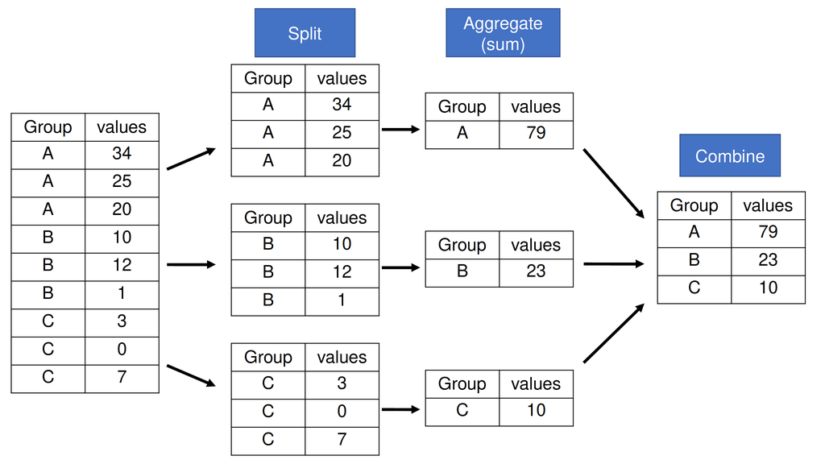

Source: https://www.dontusethiscode.com/blog/2022-09-21_groupby-split-apply-combine.html

```python
sectors = fortune.groupby('Sector')
sectors
```

```
<pandas.core.groupby.generic.DataFrameGroupBy object at 0x000001CCD6A307D0>
```

```python
len(sectors)
```

```
21
```

```python
sectors.size()
```

```
Sector
Aerospace & Defense               19
Apparel                           15
Business Services                 59
Chemicals                         26
Energy                           107
Engineering & Construction        31
Financials                       163
Food & Drug Stores                 9
Food, Beverages & Tobacco         35
Health Care                       80
Hotels, Restaurants & Leisure     29
Household Products                20
Industrials                       48
Materials                         47
Media                             26
Motor Vehicles & Parts            21
Retailing                         72
Technology                       115
Telecommunications                 9
Transportation                    39
Wholesalers                       30
dtype: int64
```

```python
sectors.first()  # first row in each group
sectors.last()   # last row in each group
```

| Sector | Company | Industry | Number_of_employees | Revenues_M | Profits_M | MarketCap_Updated_M |
| --- | --- | --- | --- | --- | --- | --- |
| Aerospace & Defense | BWX Technologies | Aerospace & Defense | 7800 | 2496.3 | 245.8 | 9380.0 |
| Apparel | Kontoor Brands | Apparel | 13700 | 2607.5 | 231.0 | 3360.0 |
| Business Services | Clear Channel Outdoor Hldgs. | Advertising, marketing | 3900 | 2489.0 | -310.9 | 798.0 |
| Chemicals | Mativ Holdings | Chemicals | 5400 | 2516.9 | -309.5 | 1018.0 |
| Energy | Talen Energy | Energy | 2000 | 2554.0 | 630.1 | 5569.0 |
| Engineering & Construction | Skyline Champion | Homebuilders | 7700 | 2606.6 | 401.8 | 4910.0 |
| Financials | AGNC Investment | Real estate | 53 | 2538.0 | 155.0 | 6887.0 |
| Food & Drug Stores | Grocery Outlet Holding | Food & Drug Stores | 949 | 3969.5 | 79.4 | 2856.0 |
| Food, Beverages & Tobacco | Universal | Tobacco | 19600 | 2569.8 | 124.1 | 1271.0 |
| Health Care | Exact Sciences | Pharmaceuticals | 6550 | 2499.8 | -204.1 | 12537.0 |
| Hotels, Restaurants & Leisure | Peloton Interactive | Toys, Sporting Goods | 3541 | 2800.2 | -1261.7 | 1572.0 |
| Household Products | Energizer Holdings | Household and Personal Products | 5080 | 2959.7 | 140.5 | 2113.0 |
| Industrials | Belden | Electronics, Electrical Equip. | 8000 | 2512.1 | 242.8 | 3805.0 |
| Materials | Carpenter Technology | Metals | 4500 | 2550.3 | 56.4 | 3529.0 |
| Media | Playtika Holding | Entertainment | 3600 | 2567.0 | 235.0 | 2613.0 |
| Motor Vehicles & Parts | Wabash National | Motor Vehicles & Parts | 6667 | 2536.5 | 231.3 | 1350.0 |
| Retailing | Etsy | Internet Services and Retailing | 2420 | 2748.4 | 307.6 | 8143.0 |
| Technology | Dropbox | Computer Software | 2693 | 2501.6 | 453.6 | 8359.0 |
| Telecommunications | Telephone & Data Systems | Telecommunications | 8800 | 5160.0 | -500.0 | 1810.0 |
| Transportation | Allegiant Travel | Airlines | 6686 | 2509.9 | 117.6 | 1375.0 |
| Wholesalers | PC Connection | Wholesalers: Electronics and Office Equipment | 2703 | 2850.6 | 83.3 | 1738.0 |

```python
sectors["Revenues_M"].sum()  # calls .agg() under the hood and then passes 'sum'

sectors["Profits_M"].max()
sectors["Profits_M"].min()

sectors["Number_of_employees"].mean()
sectors["Number_of_employees"].min()

sectors[["Revenues_M", "Profits_M"]].sum()
sectors[["Revenues_M", "Profits_M"]].mean()
```

| Sector | Revenues_M | Profits_M |
| --- | --- | --- |
| Aerospace & Defense | 20487.405263 | 1051.121053 |
| Apparel | 8706.613333 | 711.726667 |
| Business Services | 8331.708475 | 1030.001695 |
| Chemicals | 10997.780769 | 395.611538 |
| Energy | 21398.438318 | 2265.521698 |
| Engineering & Construction | 9316.077419 | 752.751613 |
| Financials | 22917.158282 | 2568.457669 |
| Food & Drug Stores | 52199.144444 | 538.833333 |
| Food, Beverages & Tobacco | 19923.931429 | 1927.680000 |
| Health Care | 38810.416250 | 2084.101250 |
| Hotels, Restaurants & Leisure | 8590.865517 | 913.134483 |
| Household Products | 11863.860000 | 1100.360000 |
| Industrials | 11961.085417 | 1607.697917 |
| Materials | 8561.502128 | 520.229787 |
| Media | 12592.030769 | 153.111538 |
| Motor Vehicles & Parts | 29126.728571 | 1520.600000 |
| Retailing | 36809.552778 | 1566.693056 |
| Technology | 21051.257391 | 3976.306140 |
| Telecommunications | 53811.300000 | 3726.788889 |
| Transportation | 15684.705128 | 1003.543590 |
| Wholesalers | 17087.440000 | 524.690000 |

#### Operations on Grouped Data

- .agg(): Pass one or more functions that reduce data (e.g., mean). Shape of final result is different from original data
  - The .agg() method applies different aggregation methods on different columns.
  - Invoke the .agg() method directly on the DataFrameGroupBy object.
  - Pass the method a dictionary where the keys are the columns and the values are the aggregation operations.
- .transform(): Pass one or more reducing (e.g., mean) or non-reducing functions (e.g., cumsum). Final result has the same shape as original data
- .apply(): Pass a reducing or non-reducing function to one or more variables.

```python
# fortune.groupby('Sector')['Number_of_employees'].mean()
fortune.groupby('Sector')['Number_of_employees'].agg('mean')
```

```
Sector
Aerospace & Defense               51402.894737
Apparel                           20885.200000
Business Services                 28992.457627
Chemicals                         19584.769231
Energy                             9051.635514
Engineering & Construction        14601.064516
Financials                        23775.907975
Food & Drug Stores               139626.555556
Food, Beverages & Tobacco         33408.400000
Health Care                       44447.600000
Hotels, Restaurants & Leisure     78097.103448
Household Products                25232.100000
Industrials                       29622.375000
Materials                         16229.744681
Media                             19636.846154
Motor Vehicles & Parts            50689.904762
Retailing                        104823.069444
Technology                        40929.469565
Telecommunications                68774.111111
Transportation                    48995.974359
Wholesalers                       17018.600000
Name: Number_of_employees, dtype: float64
```

```python
fortune.groupby('Sector')[['Revenues_M','Profits_M','MarketCap_Updated_M']].agg(['mean','std'])
```

| Sector | Revenues_M mean | Revenues_M std | Profits_M mean | Profits_M std | MarketCap_Updated_M mean | MarketCap_Updated_M std |
| --- | --- | --- | --- | --- | --- | --- |
| Aerospace & Defense | 20487.405263 | 25454.402684 | 1051.121053 | 1885.120666 | 39873.947368 | 41958.544806 |
| Apparel | 8706.613333 | 12031.825915 | 711.726667 | 1233.965949 | 14193.333333 | 26461.061904 |
| Business Services | 8331.708475 | 7356.905422 | 1030.001695 | 2889.566846 | 40366.241379 | 93072.944094 |
| Chemicals | 10997.780769 | 9822.240789 | 395.611538 | 1815.322521 | 21227.115385 | 22498.981658 |
| Energy | 21398.438318 | 44373.169392 | 2265.521698 | 4446.968618 | 30665.169811 | 59809.478664 |
| Engineering & Construction | 9316.077419 | 8411.905026 | 752.751613 | 1112.075378 | 11633.466667 | 12655.225800 |
| Financials | 22917.158282 | 43087.619124 | 2568.457669 | 8978.680192 | 46000.644444 | 102583.522649 |
| Food & Drug Stores | 52199.144444 | 58493.397637 | 538.833333 | 2044.859459 | 8954.125000 | 12306.610412 |
| Food, Beverages & Tobacco | 19923.931429 | 22283.809030 | 1927.680000 | 2811.929410 | 42276.848485 | 62662.530980 |
| Health Care | 38810.416250 | 77277.249917 | 2084.101250 | 4947.882060 | 67101.911392 | 128677.694458 |
| Hotels, Restaurants & Leisure | 8590.865517 | 7811.203808 | 913.134483 | 1780.867936 | 26785.758621 | 41661.192143 |
| Household Products | 11863.860000 | 17389.363773 | 1100.360000 | 3306.504010 | 34906.750000 | 85503.689952 |
| Industrials | 11961.085417 | 15891.987886 | 1607.697917 | 2967.855425 | 30421.000000 | 40597.884361 |
| Materials | 8561.502128 | 6578.911468 | 520.229787 | 837.501796 | 10711.787234 | 9837.680751 |
| Media | 12592.030769 | 18853.306131 | 153.111538 | 1463.405049 | 27821.160000 | 63442.605708 |
| Motor Vehicles & Parts | 29126.728571 | 52471.070160 | 1520.600000 | 4189.143686 | 49836.761905 | 174199.544438 |
| Retailing | 36809.552778 | 104269.316646 | 1566.693056 | 4446.588082 | 61210.763889 | 248837.038058 |
| Technology | 21051.257391 | 51066.528065 | 3976.306140 | 13842.232080 | 176897.008696 | 585854.886112 |
| Telecommunications | 53811.300000 | 56219.302661 | 3726.788889 | 8544.009669 | 58281.333333 | 73143.463614 |
| Transportation | 15684.705128 | 22386.726974 | 1003.543590 | 1732.477526 | 19776.435897 | 33279.943507 |
| Wholesalers | 17087.440000 | 18319.843401 | 524.690000 | 482.967845 | 10672.103448 | 12692.967365 |

```python
#fortune.groupby('Sector').agg(Total_Employees = ('Number_of_employees', 'sum'),
#                              Average_Revenue_for_Sector = ('Profits_M','median'))
fortune.groupby("Sector").agg({ "Revenues_M":"sum", "Profits_M":"max", "Number_of_employees":"mean" })
```

| Sector | Revenues_M | Profits_M | Number_of_employees |
| --- | --- | --- | --- |
| Aerospace & Defense | 389260.7 | 6920.0 | 51402.894737 |
| Apparel | 130599.2 | 5070.0 | 20885.200000 |
| Business Services | 491570.8 | 17273.0 | 28992.457627 |
| Chemicals | 285942.3 | 2388.8 | 19584.769231 |
| Energy | 2289632.9 | 36010.0 | 9051.635514 |
| Engineering & Construction | 288798.4 | 4745.7 | 14601.064516 |
| Financials | 3735496.8 | 96223.0 | 23775.907975 |
| Food & Drug Stores | 469792.3 | 4349.0 | 139626.555556 |
| Food, Beverages & Tobacco | 697337.6 | 10714.0 | 33408.400000 |
| Health Care | 3104833.3 | 35153.0 | 44447.600000 |
| Hotels, Restaurants & Leisure | 249135.1 | 8468.8 | 78097.103448 |
| Household Products | 237277.2 | 14653.0 | 25232.100000 |
| Industrials | 574132.1 | 13219.0 | 29622.375000 |
| Materials | 402390.6 | 4524.8 | 16229.744681 |
| Media | 327392.8 | 5408.0 | 19636.846154 |
| Motor Vehicles & Parts | 611661.3 | 14997.0 | 50689.904762 |
| Retailing | 2650287.8 | 30425.0 | 104823.069444 |
| Technology | 2420894.6 | 96995.0 | 40929.469565 |
| Telecommunications | 484301.7 | 15388.0 | 68774.111111 |
| Transportation | 611703.5 | 6708.0 | 48995.974359 |
| Wholesalers | 512623.2 | 1829.0 | 17018.600000 |

```python
fortune.groupby('Sector')['Number_of_employees'].transform('mean')
```

```
Rank
1       104823.069444
2       104823.069444
3        40929.469565
4        44447.600000
5        23775.907975
            ...
996      48995.974359
997      40929.469565
998      44447.600000
999      51402.894737
1000     28992.457627
Name: Number_of_employees, Length: 1000, dtype: float64
```

```python
fortune.groupby('Sector')[['Number_of_employees', 'Revenues_M','Profits_M']].apply('mean')
```

| Sector | Number_of_employees | Revenues_M | Profits_M |
| --- | --- | --- | --- |
| Aerospace & Defense | 51402.894737 | 20487.405263 | 1051.121053 |
| Apparel | 20885.200000 | 8706.613333 | 711.726667 |
| Business Services | 28992.457627 | 8331.708475 | 1030.001695 |
| Chemicals | 19584.769231 | 10997.780769 | 395.611538 |
| Energy | 9051.635514 | 21398.438318 | 2265.521698 |
| Engineering & Construction | 14601.064516 | 9316.077419 | 752.751613 |
| Financials | 23775.907975 | 22917.158282 | 2568.457669 |
| Food & Drug Stores | 139626.555556 | 52199.144444 | 538.833333 |
| Food, Beverages & Tobacco | 33408.400000 | 19923.931429 | 1927.680000 |
| Health Care | 44447.600000 | 38810.416250 | 2084.101250 |
| Hotels, Restaurants & Leisure | 78097.103448 | 8590.865517 | 913.134483 |
| Household Products | 25232.100000 | 11863.860000 | 1100.360000 |
| Industrials | 29622.375000 | 11961.085417 | 1607.697917 |
| Materials | 16229.744681 | 8561.502128 | 520.229787 |
| Media | 19636.846154 | 12592.030769 | 153.111538 |
| Motor Vehicles & Parts | 50689.904762 | 29126.728571 | 1520.600000 |
| Retailing | 104823.069444 | 36809.552778 | 1566.693056 |
| Technology | 40929.469565 | 21051.257391 | 3976.306140 |
| Telecommunications | 68774.111111 | 53811.300000 | 3726.788889 |
| Transportation | 48995.974359 | 15684.705128 | 1003.543590 |
| Wholesalers | 17018.600000 | 17087.440000 | 524.690000 |

```python
fortune.groupby(['Sector','Industry'])['Number_of_employees'].apply('median')
```

```
Sector               Industry
Aerospace & Defense  Aerospace & Defense                              20655.0
Apparel              Apparel                                          15230.0
Business Services    Advertising, marketing                           45000.0
                     Diversified Outsourcing Services                 19031.0
                     Education                                        17006.0
                                                                       ...
Transportation       Transportation and Logistics                     18452.0
                     Trucking, Truck Leasing                          15000.0
Wholesalers          Wholesalers: Diversified                          7300.0
                     Wholesalers: Electronics and Office Equipment    15800.0
                     Wholesalers: Food and Grocery                    29727.5
Name: Number_of_employees, Length: 79, dtype: float64
```

### Pivot Table

- Create a spreadsheet-style pivot table as a DataFrame

```python
fortune.pivot_table(index = 'Sector',
                    values=['Revenues_M','Profits_M'],
                    aggfunc='mean')
```

| Sector | Profits_M | Revenues_M |
| --- | --- | --- |
| Aerospace & Defense | 1051.121053 | 20487.405263 |
| Apparel | 711.726667 | 8706.613333 |
| Business Services | 1030.001695 | 8331.708475 |
| Chemicals | 395.611538 | 10997.780769 |
| Energy | 2265.521698 | 21398.438318 |
| Engineering & Construction | 752.751613 | 9316.077419 |
| Financials | 2568.457669 | 22917.158282 |
| Food & Drug Stores | 538.833333 | 52199.144444 |
| Food, Beverages & Tobacco | 1927.680000 | 19923.931429 |
| Health Care | 2084.101250 | 38810.416250 |
| Hotels, Restaurants & Leisure | 913.134483 | 8590.865517 |
| Household Products | 1100.360000 | 11863.860000 |
| Industrials | 1607.697917 | 11961.085417 |
| Materials | 520.229787 | 8561.502128 |
| Media | 153.111538 | 12592.030769 |
| Motor Vehicles & Parts | 1520.600000 | 29126.728571 |
| Retailing | 1566.693056 | 36809.552778 |
| Technology | 3976.306140 | 21051.257391 |
| Telecommunications | 3726.788889 | 53811.300000 |
| Transportation | 1003.543590 | 15684.705128 |
| Wholesalers | 524.690000 | 17087.440000 |

```python
fortune.pivot_table(index = 'Sector',
                    values=['Revenues_M','Profits_M'],
                    aggfunc='mean',
                    margins=True,
                    margins_name='Overall Mean')
```

| Sector | Profits_M | Revenues_M |
| --- | --- | --- |
| Aerospace & Defense | 1051.121053 | 20487.405263 |
| Apparel | 711.726667 | 8706.613333 |
| Business Services | 1030.001695 | 8331.708475 |
| Chemicals | 395.611538 | 10997.780769 |
| Energy | 2265.521698 | 21398.438318 |
| Engineering & Construction | 752.751613 | 9316.077419 |
| Financials | 2568.457669 | 22917.158282 |
| Food & Drug Stores | 538.833333 | 52199.144444 |
| Food, Beverages & Tobacco | 1927.680000 | 19923.931429 |
| Health Care | 2084.101250 | 38810.416250 |
| Hotels, Restaurants & Leisure | 913.134483 | 8590.865517 |
| Household Products | 1100.360000 | 11863.860000 |
| Industrials | 1607.697917 | 11961.085417 |
| Materials | 520.229787 | 8561.502128 |
| Media | 153.111538 | 12592.030769 |
| Motor Vehicles & Parts | 1520.600000 | 29126.728571 |
| Retailing | 1566.693056 | 36809.552778 |
| Technology | 3976.306140 | 21051.257391 |
| Telecommunications | 3726.788889 | 53811.300000 |
| Transportation | 1003.543590 | 15684.705128 |
| Wholesalers | 524.690000 | 17087.440000 |
| Overall Mean | 1867.165832 | 21000.751202 |

## Visualize

- Pandas is built on top of numpy and matplotlib.
- As a result, a number of plotting functions are accessible as pandas methods.
- To illustrate, we will construct a histogram, bar chart and scatterplot.

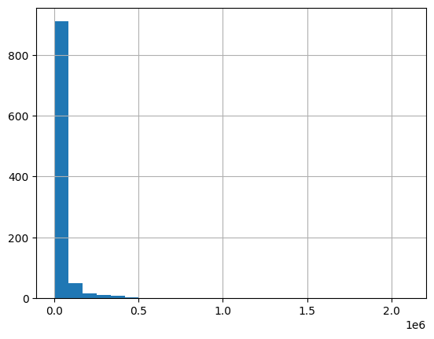

```python
import matplotlib.pyplot as plt
fortune.Number_of_employees.hist(bins = 25)
plt.show()
```

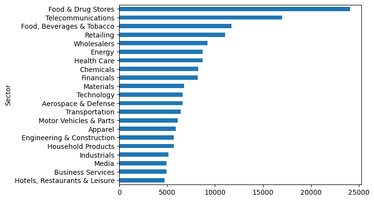

```python
fortune.groupby('Sector').Revenues_M.median().sort_values().plot(kind = 'barh')
plt.show()
```

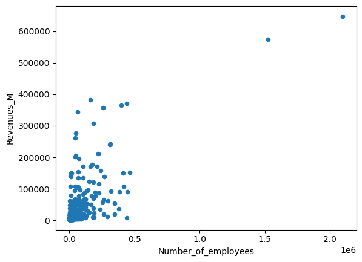

```python
fortune.plot(x = 'Number_of_employees', y = 'Revenues_M', kind = 'scatter')
plt.show()
```

## Summary

This note examined methods for exploring data, a crucial first step in machine learning.

This file was generated using Python 3.13.5 on Windows 10 with the following libraries: matplotlib 3.10.3, numpy 2.3.1, pandas 2.3.0